# Rapport - Données manquantes

#### Nom et Prénom des étudiants du groupe :

[output not shown]

### 1. Introduction

Présentation des données et objectifs de l’étude

https://www.kaggle.com/uciml/pima-indians-diabetes-database

#### Context

This dataset is originally from the National Institute of Diabetes and Digestive and Kidney Diseases. The objective of the dataset is to diagnostically predict whether or not a patient has diabetes, based on certain diagnostic measurements included in the dataset. Several constraints were placed on the selection of these instances from a larger database. In particular, all patients here are females at least 21 years old of Pima Indian heritage.

The datasets consists of several medical predictor variables and one target variable, Outcome. Predictor variables includes the number of pregnancies the patient has had, their BMI, insulin level, age, and so on.

#### Description des colonnes

- npreg : PregnanciesNumber of times pregnant
- glu : GlucosePlasma glucose concentration a 2 hours in an oral glucose tolerance test
- bp : BloodPressureDiastolic blood pressure (mm Hg)
- skin : SkinThicknessTriceps skin fold thickness (mm)
- Insuline : Insulin2-Hour serum insulin (mu U/ml)
- bmi : BMIBody mass index (weight in kg/(height in m)^2)
- ped : DiabetesPedigreeFunctionDiabetes pedigree function
- age : AgeAge (years)
- type : OutcomeClass variable (0 or 1) 268 of 768 are 1, the others are 0

### Objectifs

Prédire si l’individu a le diabête ou pas. Construire un modèle dans ce but. Auparavant compléter les données manquante par imputation multiple.

#### Chargement des donnés - Résumé

[output not shown]

[output not shown]

```r
data<-read.table("Pima_DataWithNA.txt",sep=";" ,header=T, na.strings = "NA")
#View(data)
summary(data)
```

```
##        Id            npreg             glu              bp
##  Min.   :  1.0   Min.   : 0.000   Min.   : 44.0   Min.   : 24.00
##  1st Qu.:192.8   1st Qu.: 1.000   1st Qu.: 99.0   1st Qu.: 64.00
##  Median :384.5   Median : 3.000   Median :117.0   Median : 72.00
##  Mean   :384.5   Mean   : 3.845   Mean   :121.7   Mean   : 72.41
##  3rd Qu.:576.2   3rd Qu.: 6.000   3rd Qu.:141.0   3rd Qu.: 80.00
##  Max.   :768.0   Max.   :17.000   Max.   :199.0   Max.   :122.00
##                                   NA's   :5       NA's   :35
##       skin          Insuline           bmi             ped
##  Min.   : 7.00   Min.   : 14.00   Min.   :18.20   Min.   :0.0780
##  1st Qu.:22.00   1st Qu.: 76.25   1st Qu.:27.50   1st Qu.:0.2437
##  Median :29.00   Median :125.00   Median :32.30   Median :0.3725
##  Mean   :29.15   Mean   :155.55   Mean   :32.46   Mean   :0.4719
##  3rd Qu.:36.00   3rd Qu.:190.00   3rd Qu.:36.60   3rd Qu.:0.6262
##  Max.   :99.00   Max.   :846.00   Max.   :67.10   Max.   :2.4200
##  NA's   :227     NA's   :374      NA's   :11
##       age             type
##  Min.   :21.00   Min.   :0.000
##  1st Qu.:24.00   1st Qu.:0.000
##  Median :29.00   Median :0.000
##  Mean   :33.24   Mean   :0.349
##  3rd Qu.:41.00   3rd Qu.:1.000
##  Max.   :81.00   Max.   :1.000
##
```

- Traitement des données

```r
#suppression de la 1er colonne (Id) et de la 6ème (Insuline)=> trop de données manquantes (peourrait être considérés dans un 2nd tps)
tab_Pima1<-data[,-1]
tab_Pima1<-tab_Pima1[,-5]
maxDim<-8 #8 si on décide de supprimer la colonne insuline 9 sinon

data_Pima1<-as.data.frame.matrix(tab_Pima1)

data_Pima1$type <- as.logical(data_Pima1$type)

dataPima<-data_Pima1[,1:maxDim]

dataPima<- as.data.frame(dataPima)
summary(dataPima)
```

```
##      npreg             glu              bp              skin
##  Min.   : 0.000   Min.   : 44.0   Min.   : 24.00   Min.   : 7.00
##  1st Qu.: 1.000   1st Qu.: 99.0   1st Qu.: 64.00   1st Qu.:22.00
##  Median : 3.000   Median :117.0   Median : 72.00   Median :29.00
##  Mean   : 3.845   Mean   :121.7   Mean   : 72.41   Mean   :29.15
##  3rd Qu.: 6.000   3rd Qu.:141.0   3rd Qu.: 80.00   3rd Qu.:36.00
##  Max.   :17.000   Max.   :199.0   Max.   :122.00   Max.   :99.00
##                   NA's   :5       NA's   :35       NA's   :227
##       bmi             ped              age           type
##  Min.   :18.20   Min.   :0.0780   Min.   :21.00   Mode :logical
##  1st Qu.:27.50   1st Qu.:0.2437   1st Qu.:24.00   FALSE:500
##  Median :32.30   Median :0.3725   Median :29.00   TRUE :268
##  Mean   :32.46   Mean   :0.4719   Mean   :33.24
##  3rd Qu.:36.60   3rd Qu.:0.6262   3rd Qu.:41.00
##  Max.   :67.10   Max.   :2.4200   Max.   :81.00
##  NA's   :11
```

```r
#View(data_Pima1)
```

- On marque les différentes catégories de données manquantes pour en garder la trace

### 2. Exploration des données

```
https://www.kaggle.com/laozhang/statistical-learning-with-r
https://www.kaggle.com/naveenkhasa/pima-indian-diabetes-dataset
```

#### Classification des données manqunates: MCAR/MNAR

https://datascienceplus.com/imputing-missing-data-with-r-mice-package/

Using mice for looking at missing data pattern The mice package provides a nice function md.pattern() to get a better understanding of the pattern of missing data

```r
library(mice)
pattern<-md.pattern(dataPima)
```

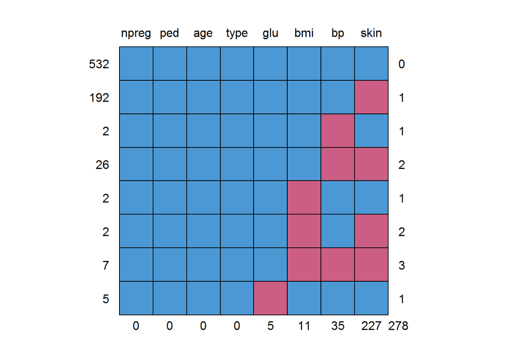

A perhaps more helpful visual representation can be obtained using the VIM package as follows

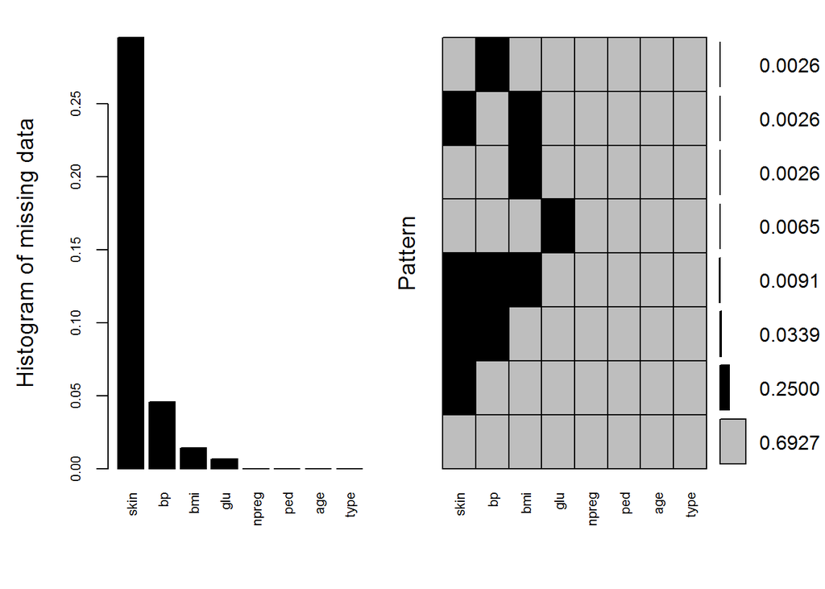

```
##
##  Variables sorted by number of missings:
##  Variable       Count
##      skin 0.295572917
##        bp 0.045572917
##       bmi 0.014322917
##       glu 0.006510417
##     npreg 0.000000000
##       ped 0.000000000
##       age 0.000000000
##      type 0.000000000
```

```r
library(VIM)
aggr_plot <- aggr(dataPima, col=c('grey','black'), numbers=TRUE, sortVars=TRUE, labels=names(dataPima), cex.axis=.7, gap=3, ylab=c("Histogram of missing data","Pattern"))
```

Another (hopefully) helpful visual approach is a special box plot

[figure not shown]

```r
par(mfrow=c(1,2))
marginplot(data[c(4,5)])
marginplot(data[c(7,5)])
```

```r
#marginplot(data[c(5,8)])
```

### 3. Imputation

Dans un premier temps on traite les valeurs manquantes. A partir des jeux de données complétés par imputation (test de différents méthodes) simple ou multiple on construit un modèle de type logit pour la variable réponse. Dans notre cas Le patient est diabétique ou pas.

#### 3.1 Imputation simple

#### 3.2 Imputation multiple avec MIPCA

- Détermination de la dimension de l’espace de projection

```r
nb.kfold$ncp
```

```
## [1] 5
```

```r
nb_Pima1$ncp
```

```
## [1] 1
```

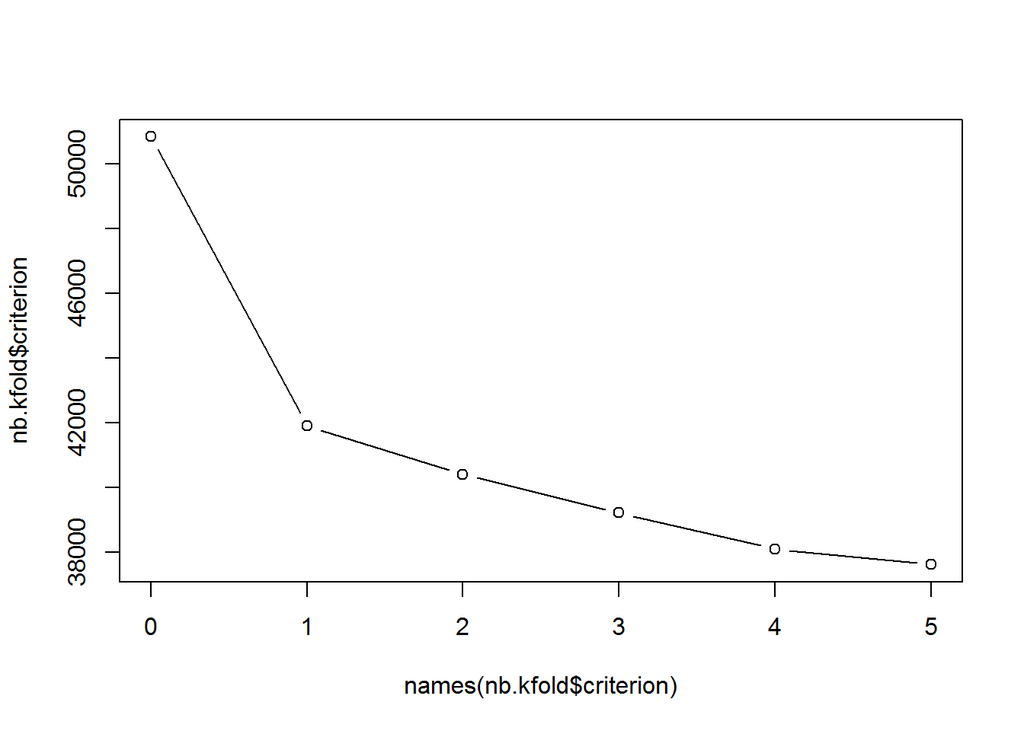

```r
plot(names(nb.kfold$criterion),nb.kfold$criterion,type="b")
```

nb_Pima1 = 1 nb.kfold$ncp = 5 avec insuline=>4

big différence! Les résultats sont meilleur avec 5

Peut être utilser 4

```r
#setting des variables
ncp.res<-nb.kfold$ncp
#ncp.res<-nb_Pima1$ncp
#dataImp<-data_Pima1[,1:maxDim]
dataPima<-data_Pima1[,1:maxDim]
```

#### 3.2.1 Multiple Imputation with Bayesian method

En changeant le nb de dimensions : de 1 à 5 le résultat est meilleur Pb pour la variabble ped mais peu d’individus concernés => ped>1.5

#### 3.2.2 Multiple Imputation with Bayesian method et EM

=> pas vraiment d’améliorations

```r
res.over_EMBayes_Pima1<-Overimpute(res.EMBayesMIPCA_Pima1)
```

#### 3.2.3 Multiple Imputation with Boost method

Le résultat semble meilleur

```r
## Diagnostics
res.overBoot_Pima1<-Overimpute(res.EMBootMIPCA_Pima1)
```

#### 3.2.4 Multiple Imputation with MIPCA Boost method

Le obtenu par boostrap et method= “EM” semble le meilleur résultat

```r
## Diagnostics
res.overEMBoot_Pima1<-Overimpute(res.EMBootMIPCA_Pima1)
```

[figure not shown]

```r
## Diagnostics
plot(res.EMBootMIPCA_Pima1)
```

#### 3.3 Imputation multiple autres méthodes - mice

Finalement le MIFAMD ne semble pas approprié Peut-être tester d’autres méthodes du package MICE par exemple…

https://datascienceplus.com/imputing-missing-data-with-r-mice-package/

```
## Class: mids
## Number of multiple imputations:  5
## Imputation methods:
## npreg   glu    bp  skin   bmi   ped   age  type
##    "" "pmm" "pmm" "pmm" "pmm"    ""    ""    ""
## PredictorMatrix:
##       npreg glu bp skin bmi ped age type
## npreg     0   1  1    1   1   1   1    1
## glu       1   0  1    1   1   1   1    1
## bp        1   1  0    1   1   1   1    1
## skin      1   1  1    0   1   1   1    1
## bmi       1   1  1    1   0   1   1    1
## ped       1   1  1    1   1   0   1    1
```

- Inspecting the distribution of original and imputed data avec MICE

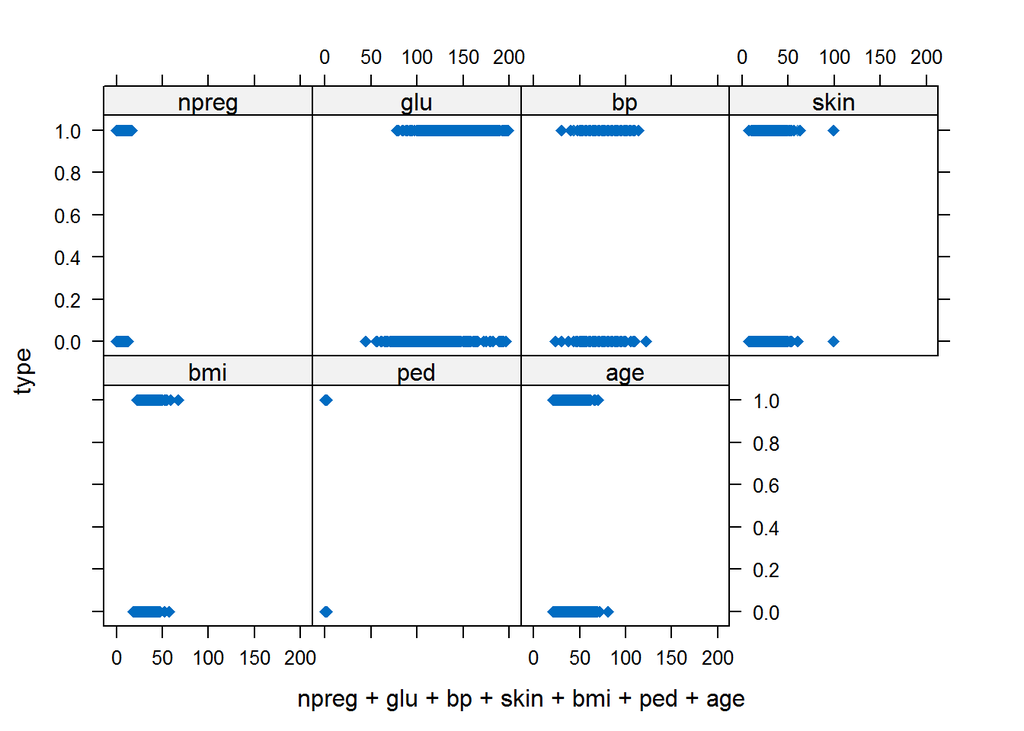

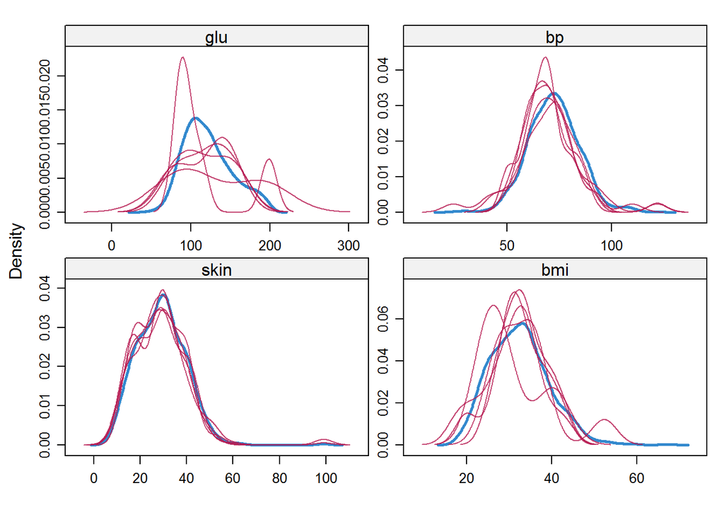

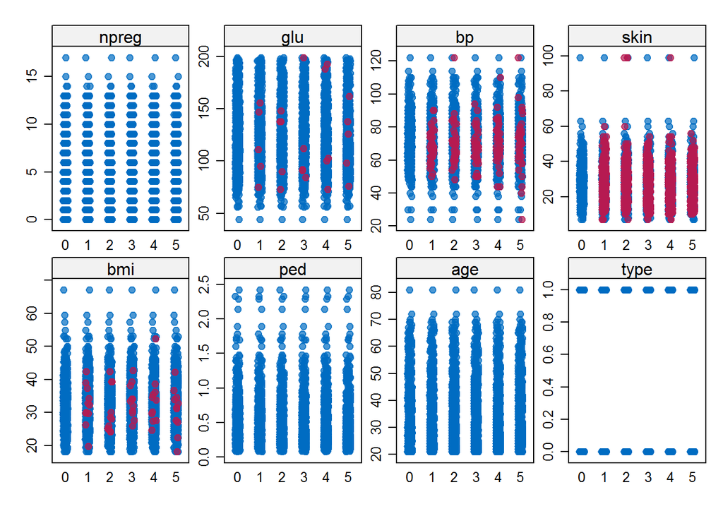

#### 3.4 Remarques :

- Comparaison des données complétées (par MIPCA et mice) aux données de la librairie MASS (sous échantillon) - Etude des Correlation

Avec MIPCA on obtient 2 individus abérrants: le 685 et 454 qui ont des valeurs négatives pour skin et bmi

```
##      npreg             glu               bp              skin
##  Min.   : 0.000   Min.   : 56.00   Min.   : 24.00   Min.   : 7.00
##  1st Qu.: 1.000   1st Qu.: 98.75   1st Qu.: 64.00   1st Qu.:22.00
##  Median : 2.000   Median :115.00   Median : 72.00   Median :29.00
##  Mean   : 3.517   Mean   :121.03   Mean   : 71.51   Mean   :29.18
##  3rd Qu.: 5.000   3rd Qu.:141.25   3rd Qu.: 80.00   3rd Qu.:36.00
##  Max.   :17.000   Max.   :199.00   Max.   :110.00   Max.   :99.00
##       bmi             ped              age         type
##  Min.   :18.20   Min.   :0.0850   Min.   :21.00   No :355
##  1st Qu.:27.88   1st Qu.:0.2587   1st Qu.:23.00   Yes:177
##  Median :32.80   Median :0.4160   Median :28.00
##  Mean   :32.89   Mean   :0.5030   Mean   :31.61
##  3rd Qu.:36.90   3rd Qu.:0.6585   3rd Qu.:38.00
##  Max.   :67.10   Max.   :2.4200   Max.   :81.00
```

```
##      npreg             glu              bp              skin
##  Min.   : 0.000   Min.   : 44.0   Min.   : 24.00   Min.   : 5.849
##  1st Qu.: 1.000   1st Qu.: 99.0   1st Qu.: 64.00   1st Qu.:20.159
##  Median : 3.000   Median :117.0   Median : 72.00   Median :29.000
##  Mean   : 3.856   Mean   :121.7   Mean   : 71.97   Mean   :28.726
##  3rd Qu.: 6.000   3rd Qu.:141.0   3rd Qu.: 80.00   3rd Qu.:35.746
##  Max.   :17.000   Max.   :199.0   Max.   :122.00   Max.   :99.000
##
##       bmi             ped              age           type
##  Min.   :18.20   Min.   :0.0780   Min.   :21.00   Mode :logical
##  1st Qu.:27.60   1st Qu.:0.2425   1st Qu.:24.00   FALSE:496
##  Median :32.40   Median :0.3705   Median :29.00   TRUE :268
##  Mean   :32.53   Mean   :0.4713   Mean   :33.11
##  3rd Qu.:36.60   3rd Qu.:0.6245   3rd Qu.:40.25
##  Max.   :67.10   Max.   :2.4200   Max.   :81.00
##
##       missingCateg
##  No-Missing :532
##  skin.only  :190
##  skin.bp    : 25
##  skin.bp.bmi:  7
##  glu.only   :  5
##  bp.only    :  2
##  (Other)    :  3
```

```
##      npreg             glu              bp              skin
##  Min.   : 0.000   Min.   : 44.0   Min.   : 24.00   Min.   : 7.00
##  1st Qu.: 1.000   1st Qu.: 99.0   1st Qu.: 64.00   1st Qu.:21.75
##  Median : 3.000   Median :117.0   Median : 72.00   Median :29.00
##  Mean   : 3.845   Mean   :121.7   Mean   : 72.24   Mean   :28.94
##  3rd Qu.: 6.000   3rd Qu.:141.0   3rd Qu.: 80.00   3rd Qu.:36.00
##  Max.   :17.000   Max.   :199.0   Max.   :122.00   Max.   :99.00
##       bmi             ped              age           type
##  Min.   :18.20   Min.   :0.0780   Min.   :21.00   Mode :logical
##  1st Qu.:27.50   1st Qu.:0.2437   1st Qu.:24.00   FALSE:500
##  Median :32.30   Median :0.3725   Median :29.00   TRUE :268
##  Mean   :32.45   Mean   :0.4719   Mean   :33.24
##  3rd Qu.:36.60   3rd Qu.:0.6262   3rd Qu.:41.00
##  Max.   :67.10   Max.   :2.4200   Max.   :81.00
```

Les correlations très voisines, tendance à baisser pour les données imputés (sauf pour corr bmi / skin ) La structure globale des corrélations est très voisine.

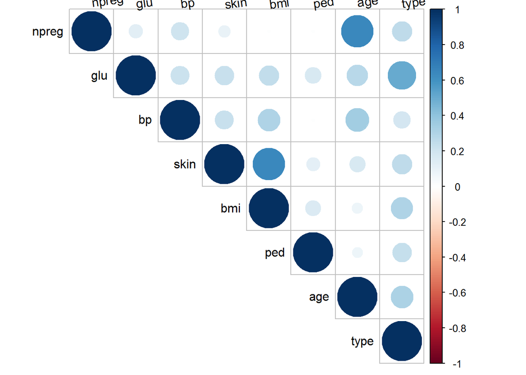

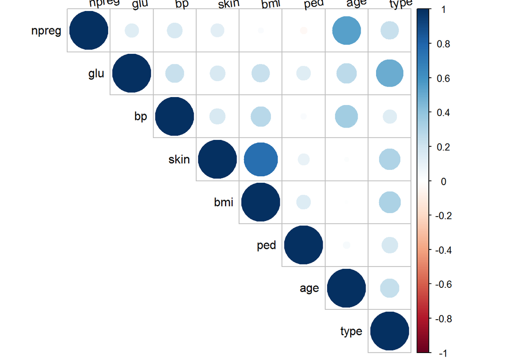

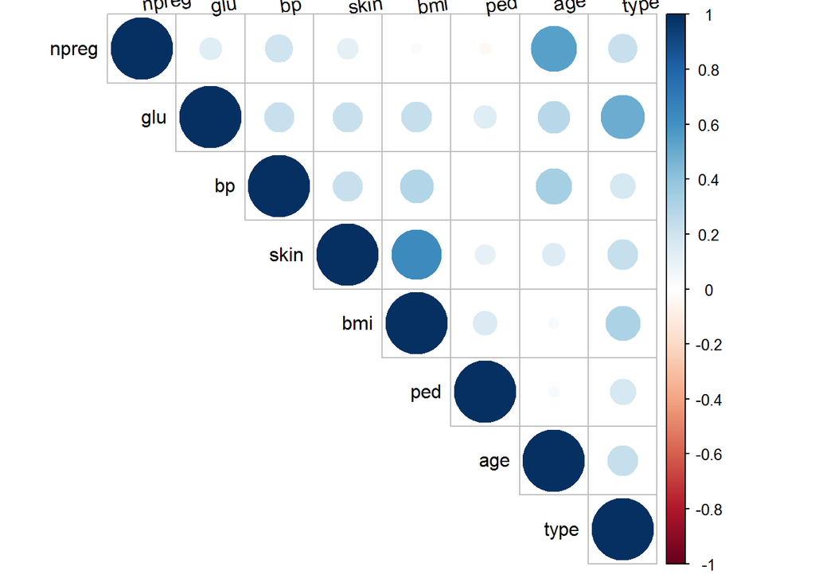

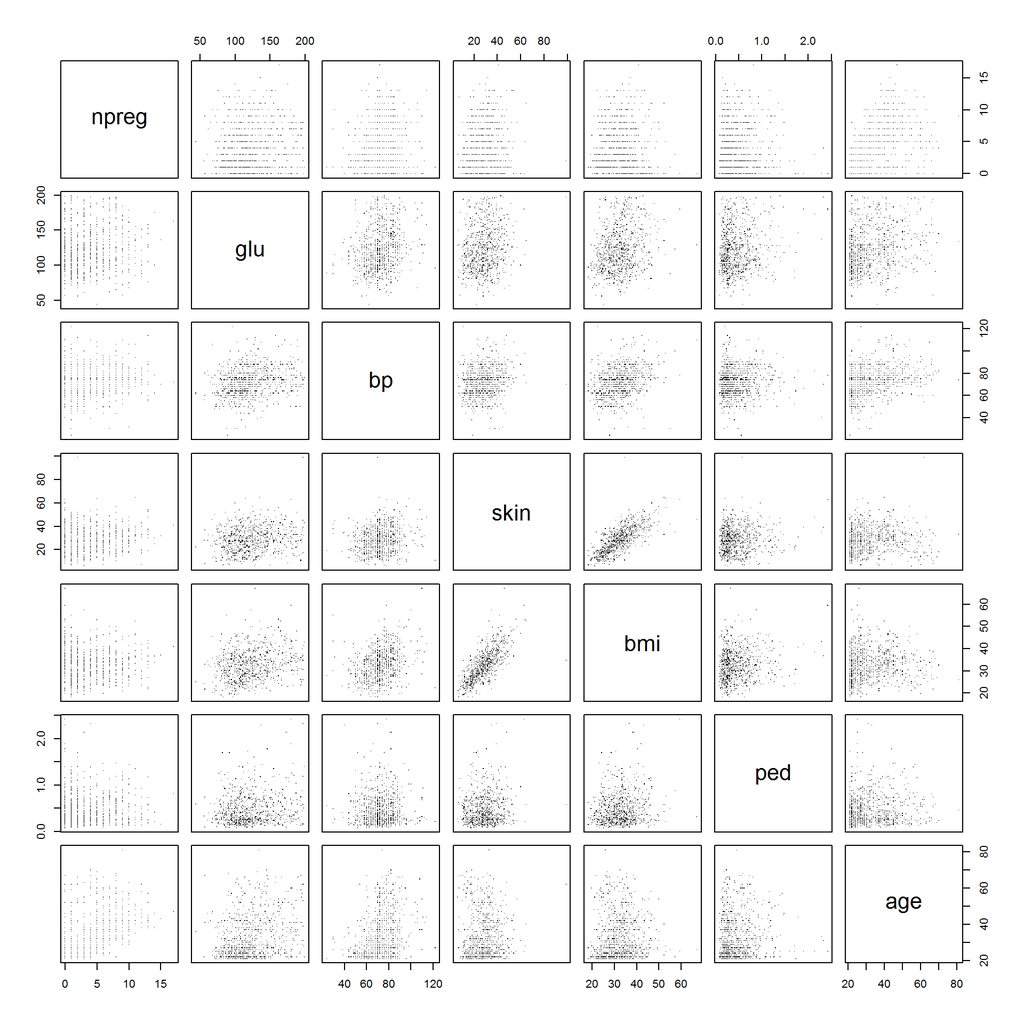

### 4. Modélisation de la variable réponse

A partir des données complétés. Le modèle de la variable réponse: “Individus diabétique” (variable “type” : Yes/No) est un modèle logit. Regression linéaire généralisé sur les variables explicatives: npreg + glu + bp + skin + bmi + ped + age

Regression on the multiply imputed data set and pooling with mice

```r
dataPima<-data_Pima1[,1:maxDim] #dataImp
#mi<-res.BayesMIPCA_Pima1
mi.res<-res.EMBootMIPCA_Pima1

imp_Pima1<-prelim(res.mi=mi.res,X=dataPima)#creating a mids object

#MICE: with.mids Evaluate an expression in multiple imputed datasets
fit_Pima1_m1 <- with(data=imp_Pima1,exp=glm(type ~ npreg + glu + bp + skin + bmi +  ped + age,family=binomial))
fit_Pima1_m2 <- with(data=imp_Pima1,exp=glm(type ~ npreg + glu + bp + bmi +  ped + age ,family=binomial))
fit_Pima1_m3 <- with(data=imp_Pima1,exp=glm(type ~ npreg + glu + skin + bmi +  ped + age,family=binomial))
fit_Pima1_m4 <- with(data=imp_Pima1,exp=glm(type ~ npreg + glu + bmi +  ped + age,family=binomial))
fit_Pima1_m5 <- with(data=imp_Pima1,exp=glm(type ~ npreg + glu + bmi +  ped ,family=binomial))
fit_Pima1_m6 <- with(data=imp_Pima1,exp=glm(type ~ npreg + glu + bmi +  ped ,family=binomial))
fit_Pima1_m7 <- with(data=imp_Pima1,exp=glm(type ~ npreg + glu + ped ,family=binomial))
fit_Pima1_m8 <- with(data=imp_Pima1,exp=glm(type ~ glu + ped ,family=binomial))
#anova.imp <- with(data=imp_Pima1,exp=anova(lm(type ~ npreg + glu + bp + skin + bmi +  ped + age)))
```

#### Choix du modèle - anova

```r
anova(fit_Pima1_m1,fit_Pima1_m2)
```

```
##    test statistic df1      df2 df.com    p.value       riv
##  1 ~~ 2  2.922331   1 334.2003    760 0.08828984 0.6550675
```

```r
anova(fit_Pima1_m1,fit_Pima1_m3)
```

```
##    test statistic df1      df2 df.com    p.value       riv
##  1 ~~ 2  4.053477   1 606.6422    760 0.04452163 0.2110133
```

```r
anova(fit_Pima1_m1,fit_Pima1_m4)
```

```
##    test statistic df1      df2 df.com    p.value       riv
##  1 ~~ 2  3.345291   2 556.0702    760 0.03596081 0.4348542
```

```r
anova(fit_Pima1_m1,fit_Pima1_m5)
```

```
##    test statistic df1      df2 df.com    p.value       riv
##  1 ~~ 2  2.854114   3 666.6338    760 0.03649841 0.2962775
```

```r
anova(fit_Pima1_m1,fit_Pima1_m6)
```

```
##    test statistic df1      df2 df.com    p.value       riv
##  1 ~~ 2  2.854114   3 666.6338    760 0.03649841 0.2962775
```

```r
anova(fit_Pima1_m1,fit_Pima1_m7)
```

```
##    test statistic df1     df2 df.com     p.value       riv
##  1 ~~ 2  7.633842   4 645.243    760 5.17546e-06 0.4260655
```

```r
anova(fit_Pima1_m1,fit_Pima1_m8)
```

```
##    test statistic df1      df2 df.com      p.value       riv
##  1 ~~ 2  9.325928   5 687.6094    760 1.312314e-08 0.3430369
```

```r
anova(fit_Pima1_m6,fit_Pima1_m8)
```

```
##    test statistic df1      df2 df.com      p.value       riv
##  1 ~~ 2    17.495   2 515.5077    763 4.454195e-08 0.5305974
```

```r
anova(fit_Pima1_m7,fit_Pima1_m8)
```

```
##    test statistic df1      df2 df.com      p.value          riv
##  1 ~~ 2   24.5119   1 762.0037    764 9.098076e-07 0.0005467638
```

Choix du plus grand modèle?

#### Choix du modèle - Utilisation de regsubsets à partir du modèle réduit m_PCA

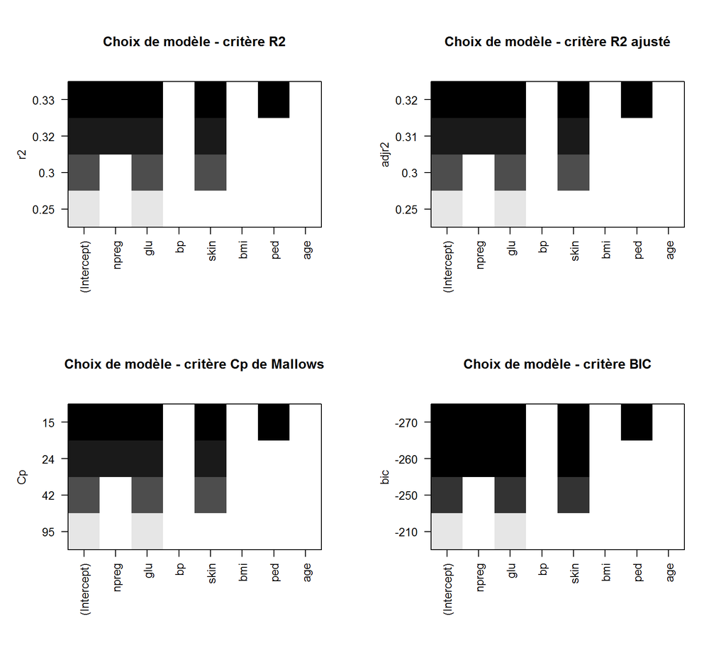

La méthode step du package leaps nous fait choisir un modèle à 4 variables explicatives: npreg + glu + skin + ped

#### Choix du modèle - méthode step du package MASS à partir du modèle saturé

```r
m_sature = glm(formula = type ~ (npreg + glu + bp + skin + bmi +  ped + age),  family = binomial(link="logit"),  data = dataFramePima)
summary(m_sature)
```

```
##
## Call:
## glm(formula = type ~ (npreg + glu + bp + skin + bmi + ped + age),
##     family = binomial(link = "logit"), data = dataFramePima)
##
## Deviance Residuals:
##     Min       1Q   Median       3Q      Max
## -2.9241  -0.6821  -0.3706   0.7029   2.3975
##
## Coefficients:
##              Estimate Std. Error z value Pr(>|z|)
## (Intercept) -8.632846   0.778941 -11.083  < 2e-16 ***
## npreg        0.093866   0.033573   2.796  0.00518 **
## glu          0.038195   0.003683  10.370  < 2e-16 ***
## bp          -0.019253   0.008215  -2.344  0.01910 *
## skin         0.041387   0.013875   2.983  0.00286 **
## bmi          0.053620   0.021553   2.488  0.01285 *
## ped          0.868827   0.301355   2.883  0.00394 **
## age          0.023759   0.010259   2.316  0.02057 *
## ---
## Signif. codes:  0 '***' 0.001 '**' 0.01 '*' 0.05 '.' 0.1 ' ' 1
##
## (Dispersion parameter for binomial family taken to be 1)
##
##     Null deviance: 990.04  on 763  degrees of freedom
## Residual deviance: 692.88  on 756  degrees of freedom
## AIC: 708.88
##
## Number of Fisher Scoring iterations: 5
```

#### Choix du modèle - Méthode progressive - step backward-forward à partir de m_sature

- Critère AIC
- Critère BIC

##### Choix du modèle - Modèle obtenu

```r
modele_step_BwdFwd_AIC<-glm(formula = type ~ (npreg + glu + bp + skin + bmi + ped + age), family = binomial, data = dataFramePima)
summary(modele_step_BwdFwd_AIC)
```

```
##
## Call:
## glm(formula = type ~ (npreg + glu + bp + skin + bmi + ped + age),
##     family = binomial, data = dataFramePima)
##
## Deviance Residuals:
##     Min       1Q   Median       3Q      Max
## -2.9241  -0.6821  -0.3706   0.7029   2.3975
##
## Coefficients:
##              Estimate Std. Error z value Pr(>|z|)
## (Intercept) -8.632846   0.778941 -11.083  < 2e-16 ***
## npreg        0.093866   0.033573   2.796  0.00518 **
## glu          0.038195   0.003683  10.370  < 2e-16 ***
## bp          -0.019253   0.008215  -2.344  0.01910 *
## skin         0.041387   0.013875   2.983  0.00286 **
## bmi          0.053620   0.021553   2.488  0.01285 *
## ped          0.868827   0.301355   2.883  0.00394 **
## age          0.023759   0.010259   2.316  0.02057 *
## ---
## Signif. codes:  0 '***' 0.001 '**' 0.01 '*' 0.05 '.' 0.1 ' ' 1
##
## (Dispersion parameter for binomial family taken to be 1)
##
##     Null deviance: 990.04  on 763  degrees of freedom
## Residual deviance: 692.88  on 756  degrees of freedom
## AIC: 708.88
##
## Number of Fisher Scoring iterations: 5
```

```r
AIC(modele_step_BwdFwd_AIC)
```

```
## [1] 708.8771
```

```r
BIC(modele_step_BwdFwd_AIC)
```

```
## [1] 745.9856
```

```r
m_StepBwdFwd_BIC<-glm(formula = type ~ (npreg + glu + skin + ped),family = binomial, data = dataFramePima)
summary(m_StepBwdFwd_BIC)
```

```
##
## Call:
## glm(formula = type ~ (npreg + glu + skin + ped), family = binomial,
##     data = dataFramePima)
##
## Deviance Residuals:
##     Min       1Q   Median       3Q      Max
## -2.9834  -0.6901  -0.3859   0.7261   2.3827
##
## Coefficients:
##              Estimate Std. Error z value Pr(>|z|)
## (Intercept) -8.231640   0.597718 -13.772  < 2e-16 ***
## npreg        0.116960   0.027239   4.294 1.76e-05 ***
## glu          0.039261   0.003539  11.093  < 2e-16 ***
## skin         0.059901   0.009551   6.272 3.57e-10 ***
## ped          0.915433   0.293756   3.116  0.00183 **
## ---
## Signif. codes:  0 '***' 0.001 '**' 0.01 '*' 0.05 '.' 0.1 ' ' 1
##
## (Dispersion parameter for binomial family taken to be 1)
##
##     Null deviance: 990.04  on 763  degrees of freedom
## Residual deviance: 705.68  on 759  degrees of freedom
## AIC: 715.68
##
## Number of Fisher Scoring iterations: 5
```

```r
AIC(m_StepBwdFwd_BIC)
```

```
## [1] 715.6793
```

```r
BIC(m_StepBwdFwd_BIC)
```

```
## [1] 738.8722
```

Avec le critère AIC on obtient le modèle saturé Avec le critère BIC on obtient à nouveau le modèle à 4 variable: npreg + glu + skin + ped

#### Pooling

https://datascienceplus.com/imputing-missing-data-with-r-mice-package/

```r
res.pool_Pima1_m1<-pool(fit_Pima1_m1);
res.pool_Pima1_m2<-pool(fit_Pima1_m2);
res.pool_Pima1_m3<-pool(fit_Pima1_m3);
res.pool_Pima1_m4<-pool(fit_Pima1_m4);
res.pool_Pima1_m5<-pool(fit_Pima1_m5);
res.pool_Pima1_m6<-pool(fit_Pima1_m6);
res.pool_Pima1_m7<-pool(fit_Pima1_m7);
res.pool_Pima1_m8<-pool(fit_Pima1_m8);
```

```r
summary(res.pool_Pima1_m1)#pooling
```

|  | estimate | std.error | statistic | df | p.value |
| --- | --- | --- | --- | --- | --- |
| (Intercept) | -8.55345184 | 0.904356019 | -9.458058 | 369.9007 | 0.000000000 |
| npreg | 0.10760301 | 0.033263791 | 3.234839 | 733.8566 | 0.001271664 |
| glu | 0.03771328 | 0.003679638 | 10.249182 | 737.7532 | 0.000000000 |
| bp | -0.01710593 | 0.008496356 | -2.013325 | 525.1253 | 0.044590181 |
| skin | 0.02330711 | 0.013634013 | 1.709483 | 265.5475 | 0.088529799 |
| bmi | 0.06670819 | 0.022484123 | 2.966902 | 369.9135 | 0.003203684 |
| ped | 0.89623524 | 0.300205009 | 2.985411 | 750.9670 | 0.002923974 |
| age | 0.01951717 | 0.009964014 | 1.958766 | 740.5210 | 0.050515157 |

```r
summary(res.pool_Pima1_m2)#pooling
```

|  | estimate | std.error | statistic | df | p.value |
| --- | --- | --- | --- | --- | --- |
| (Intercept) | -8.66745311 | 0.895306561 | -9.680989 | 379.4707 | 0.000000e+00 |
| npreg | 0.11896609 | 0.032447182 | 3.666454 | 754.8285 | 2.631831e-04 |
| glu | 0.03727912 | 0.003644620 | 10.228534 | 739.9954 | 0.000000e+00 |
| bp | -0.01702981 | 0.008345845 | -2.040513 | 544.2280 | 4.178133e-02 |
| bmi | 0.09305413 | 0.018451821 | 5.043087 | 307.3704 | 7.844189e-07 |
| ped | 0.89767594 | 0.298881221 | 3.003454 | 754.6572 | 2.757567e-03 |
| age | 0.01774668 | 0.009780090 | 1.814572 | 750.0969 | 6.998906e-02 |

```r
summary(res.pool_Pima1_m3)#pooling
```

|  | estimate | std.error | statistic | df | p.value |
| --- | --- | --- | --- | --- | --- |
| (Intercept) | -9.11694263 | 0.850123173 | -10.724261 | 390.0891 | 0.000000000 |
| npreg | 0.10841742 | 0.032989851 | 3.286387 | 735.0142 | 0.001063006 |
| glu | 0.03678817 | 0.003605913 | 10.202178 | 744.2912 | 0.000000000 |
| skin | 0.02316207 | 0.013833147 | 1.674389 | 247.7722 | 0.095315872 |
| bmi | 0.05616421 | 0.023177313 | 2.423241 | 286.3886 | 0.016002645 |
| ped | 0.90170576 | 0.297501273 | 3.030931 | 749.3808 | 0.002521943 |
| age | 0.01328008 | 0.009486303 | 1.399922 | 732.7502 | 0.161960046 |

```r
summary(res.pool_Pima1_m4)#pooling
```

|  | estimate | std.error | statistic | df | p.value |
| --- | --- | --- | --- | --- | --- |
| (Intercept) | -9.23756375 | 0.849538738 | -10.873623 | 382.6665 | 0.000000e+00 |
| npreg | 0.11944755 | 0.032158958 | 3.714285 | 756.6838 | 2.187634e-04 |
| glu | 0.03638177 | 0.003573306 | 10.181544 | 746.1056 | 0.000000e+00 |
| bmi | 0.08258663 | 0.020243274 | 4.079707 | 185.0032 | 6.696655e-05 |
| ped | 0.90400945 | 0.296197884 | 3.052046 | 753.5515 | 2.352712e-03 |
| age | 0.01157858 | 0.009259496 | 1.250455 | 752.2376 | 2.115221e-01 |

```r
summary(res.pool_Pima1_m5)#pooling
```

|  | estimate | std.error | statistic | df | p.value |
| --- | --- | --- | --- | --- | --- |
| (Intercept) | -8.99437929 | 0.813572130 | -11.055417 | 379.3701 | 0.000000e+00 |
| npreg | 0.14070799 | 0.027563539 | 5.104859 | 754.8511 | 4.194003e-07 |
| glu | 0.03728746 | 0.003507573 | 10.630559 | 749.3445 | 0.000000e+00 |
| bmi | 0.08112923 | 0.020140378 | 4.028188 | 186.3862 | 8.176268e-05 |
| ped | 0.91351691 | 0.295629384 | 3.090075 | 754.6298 | 2.074548e-03 |

```r
summary(res.pool_Pima1_m6)#pooling
```

|  | estimate | std.error | statistic | df | p.value |
| --- | --- | --- | --- | --- | --- |
| (Intercept) | -8.99437929 | 0.813572130 | -11.055417 | 379.3701 | 0.000000e+00 |
| npreg | 0.14070799 | 0.027563539 | 5.104859 | 754.8511 | 4.194003e-07 |
| glu | 0.03728746 | 0.003507573 | 10.630559 | 749.3445 | 0.000000e+00 |
| bmi | 0.08112923 | 0.020140378 | 4.028188 | 186.3862 | 8.176268e-05 |
| ped | 0.91351691 | 0.295629384 | 3.090075 | 754.6298 | 2.074548e-03 |

```r
summary(res.pool_Pima1_m7)#pooling
```

|  | estimate | std.error | statistic | df | p.value |
| --- | --- | --- | --- | --- | --- |
| (Intercept) | -6.56738912 | 0.488278949 | -13.450076 | 759.8920 | 0.000000e+00 |
| npreg | 0.13078937 | 0.026417031 | 4.950949 | 761.5897 | 9.099087e-07 |
| glu | 0.03934452 | 0.003443794 | 11.424763 | 758.9018 | 0.000000e+00 |
| ped | 1.00865283 | 0.280849535 | 3.591435 | 761.6196 | 3.499669e-04 |

```r
summary(res.pool_Pima1_m8)#pooling
```

|  | estimate | std.error | statistic | df | p.value |
| --- | --- | --- | --- | --- | --- |
| (Intercept) | -6.11254730 | 0.465391647 | -13.134201 | 759.9030 | 0.0000000000 |
| glu | 0.04026241 | 0.003414328 | 11.792192 | 759.2112 | 0.0000000000 |
| ped | 0.93003426 | 0.277798724 | 3.347871 | 762.5943 | 0.0008543002 |

### 5. Conclusion

Intérêt : Les données Pima sont très utilsées (cf. Kaggle) pour autant il ne semble pas qu’un modèle d’inputation ait été utilisé. Bien souvent les données manquantes sont supprimés ou bien imputatikon simple par moyenne.

## Annexes

### Annexe 1 : Analyse PCA - comparaison aux données non traitées

- PCA sur les données complétées par MIPCA

```
##
## Call:
## PCA(X = dataFramePima, quali.sup = 8:9, graph = FALSE)
##
##
## Eigenvalues
##                        Dim.1   Dim.2   Dim.3   Dim.4   Dim.5   Dim.6
## Variance               2.239   1.546   1.008   0.849   0.732   0.388
## % of var.             31.982  22.082  14.407  12.126  10.458   5.538
## Cumulative % of var.  31.982  54.064  68.471  80.596  91.055  96.593
##                        Dim.7
## Variance               0.239
## % of var.              3.407
## Cumulative % of var. 100.000
##
## Individuals (the 10 first)
##                 Dist    Dim.1    ctr   cos2    Dim.2    ctr   cos2
## 1           |  1.967 |  1.477  0.128  0.564 |  0.772  0.050  0.154 |
## 2           |  1.812 | -1.413  0.117  0.608 | -0.215  0.004  0.014 |
## 3           |  3.068 | -0.251  0.004  0.007 |  1.611  0.220  0.276 |
## 4           |  2.172 | -1.925  0.217  0.786 | -0.438  0.016  0.041 |
## 5           |  6.359 |  0.609  0.022  0.009 | -2.857  0.691  0.202 |
## 6           |  1.672 | -1.029  0.062  0.378 |  1.042  0.092  0.388 |
## 7           |  2.447 | -1.584  0.147  0.419 | -0.669  0.038  0.075 |
## 8           |  2.504 |  0.443  0.011  0.031 |  0.258  0.006  0.011 |
## 9           |  3.558 |  1.737  0.176  0.238 |  0.474  0.019  0.018 |
## 10          |  4.703 |  4.183  1.023  0.791 | -0.272  0.006  0.003 |
##              Dim.3    ctr   cos2
## 1            0.548  0.039  0.078 |
## 2           -0.493  0.032  0.074 |
## 3            1.737  0.392  0.321 |
## 4           -0.843  0.092  0.151 |
## 5            4.811  3.004  0.572 |
## 6           -0.420  0.023  0.063 |
## 7           -1.005  0.131  0.169 |
## 8           -1.410  0.258  0.317 |
## 9            0.016  0.000  0.000 |
## 10          -1.953  0.495  0.172 |
##
## Variables
```

[output cut: 25 more lines]

```
## skin.bp.bmi |   1.862 |  -0.853   0.210  -1.514 |  -0.672   0.130  -1.436
## bp.only     |   1.767 |  -0.112   0.004  -0.106 |   0.298   0.028   0.339
## bmi.only    |   2.673 |  -1.041   0.152  -0.985 |  -1.255   0.220  -1.428
## glu.only    |   0.675 |  -0.333   0.244  -0.499 |  -0.416   0.379  -0.750
##                 Dim.3    cos2  v.test
## FALSE       |  -0.135   0.056  -5.057 |
## TRUE        |   0.250   0.056   5.057 |
## No-Missing  |   0.063   0.094   2.629 |
## skin.only   |  -0.133   0.040  -2.106 |
## skin.bp     |  -0.100   0.020  -0.504 |
## skin.bmi    |  -1.953   0.172  -1.944 |
## skin.bp.bmi |  -1.052   0.319  -2.781 |
## bp.only     |   0.313   0.031   0.441 |
## bmi.only    |   1.882   0.496   2.652 |
## glu.only    |  -0.175   0.067  -0.391 |
```

- PCA sur les données complétées par MICE

```
##
## Call:
## PCA(X = completedData_mice, quali.sup = maxDim, graph = FALSE)
##
##
## Eigenvalues
##                        Dim.1   Dim.2   Dim.3   Dim.4   Dim.5   Dim.6
## Variance               2.252   1.470   0.992   0.800   0.727   0.430
## % of var.             32.165  21.003  14.174  11.435  10.383   6.142
## Cumulative % of var.  32.165  53.168  67.342  78.777  89.160  95.302
##                        Dim.7
## Variance               0.329
## % of var.              4.698
## Cumulative % of var. 100.000
##
## Individuals (the 10 first)
##           Dist    Dim.1    ctr   cos2    Dim.2    ctr   cos2    Dim.3
## 1     |  1.942 |  1.501  0.130  0.598 |  0.639  0.036  0.108 |  0.683
## 2     |  1.817 | -1.437  0.119  0.625 | -0.086  0.001  0.002 | -0.436
## 3     |  2.979 | -0.035  0.000  0.000 |  1.326  0.156  0.198 |  1.769
## 4     |  2.184 | -1.971  0.225  0.815 | -0.269  0.006  0.015 | -0.882
## 5     |  6.421 |  0.402  0.009  0.004 | -3.226  0.922  0.252 |  5.009
## 6     |  1.853 | -1.114  0.072  0.361 |  1.217  0.131  0.432 | -0.344
## 7     |  2.520 | -1.672  0.162  0.440 | -0.460  0.019  0.033 | -0.744
## 8     |  2.558 |  0.553  0.018  0.047 |  0.348  0.011  0.018 | -1.155
## 9     |  3.549 |  1.793  0.186  0.255 |  0.307  0.008  0.007 | -0.044
## 10    |  3.738 |  3.273  0.620  0.767 |  0.577  0.029  0.024 | -1.512
##          ctr   cos2
## 1      0.061  0.124 |
## 2      0.025  0.058 |
## 3      0.411  0.352 |
## 4      0.102  0.163 |
## 5      3.293  0.608 |
## 6      0.016  0.035 |
## 7      0.073  0.087 |
## 8      0.175  0.204 |
## 9      0.000  0.000 |
## 10     0.300  0.164 |
##
## Variables
```

[output cut: 9 more lines]

```
## npreg |
## glu   |
## bp    |
## skin  |
## bmi   |
## ped   |
## age   |
##
## Supplementary categories
##            Dist     Dim.1    cos2  v.test     Dim.2    cos2  v.test
## FALSE |   0.552 |  -0.510   0.853 -12.856 |   0.026   0.002   0.817 |
## TRUE  |   1.030 |   0.951   0.853  12.856 |  -0.049   0.002  -0.817 |
##         Dim.3    cos2  v.test
## FALSE  -0.133   0.058  -5.053 |
## TRUE    0.248   0.058   5.053 |
```

- PCA sur les données Pima de MASS (non imputées)

```
##
## Call:
## PCA(X = dataPimaMASS, quali.sup = 8, graph = FALSE)
##
##
## Eigenvalues
##                        Dim.1   Dim.2   Dim.3   Dim.4   Dim.5   Dim.6
## Variance               2.316   1.500   1.007   0.800   0.717   0.349
## % of var.             33.092  21.434  14.386  11.430  10.242   4.984
## Cumulative % of var.  33.092  54.526  68.912  80.342  90.584  95.568
##                        Dim.7
## Variance               0.310
## % of var.              4.432
## Cumulative % of var. 100.000
##
## Individuals (the 10 first)
##           Dist    Dim.1    ctr   cos2    Dim.2    ctr   cos2    Dim.3
## 1     |  1.547 | -0.964  0.075  0.389 | -0.249  0.008  0.026 | -0.577
## 2     |  3.735 |  1.663  0.224  0.198 | -2.123  0.564  0.323 |  0.219
## 3     |  2.347 |  0.618  0.031  0.069 | -0.038  0.000  0.000 | -1.859
## 4     |  3.248 |  1.446  0.170  0.198 |  2.378  0.708  0.536 | -0.914
## 5     |  2.249 | -2.006  0.327  0.796 |  0.196  0.005  0.008 | -0.576
## 6     |  2.205 |  0.865  0.061  0.154 | -1.201  0.181  0.297 | -0.609
## 7     |  1.850 | -1.135  0.104  0.376 |  0.478  0.029  0.067 | -0.586
## 8     |  3.513 | -1.326  0.143  0.143 |  0.054  0.000  0.000 |  2.053
## 9     |  3.476 |  0.995  0.080  0.082 | -2.110  0.558  0.368 | -0.317
## 10    |  2.789 |  1.411  0.162  0.256 |  1.692  0.359  0.368 |  1.291
##          ctr   cos2
## 1      0.062  0.139 |
## 2      0.009  0.003 |
## 3      0.645  0.627 |
## 4      0.156  0.079 |
## 5      0.062  0.066 |
## 6      0.069  0.076 |
## 7      0.064  0.100 |
## 8      0.787  0.342 |
## 9      0.019  0.008 |
## 10     0.311  0.214 |
##
## Variables
```

[output cut: 9 more lines]

```
## npreg |
## glu   |
## bp    |
## skin  |
## bmi   |
## ped   |
## age   |
##
## Supplementary categories
##            Dist     Dim.1    cos2  v.test     Dim.2    cos2  v.test
## No    |   0.574 |  -0.536   0.872 -11.491 |  -0.009   0.000  -0.238 |
## Yes   |   1.151 |   1.075   0.872  11.491 |   0.018   0.000   0.238 |
##         Dim.3    cos2  v.test
## No     -0.156   0.074  -5.089 |
## Yes     0.314   0.074   5.089 |
```

#### 1. Choix du nombre d’axes

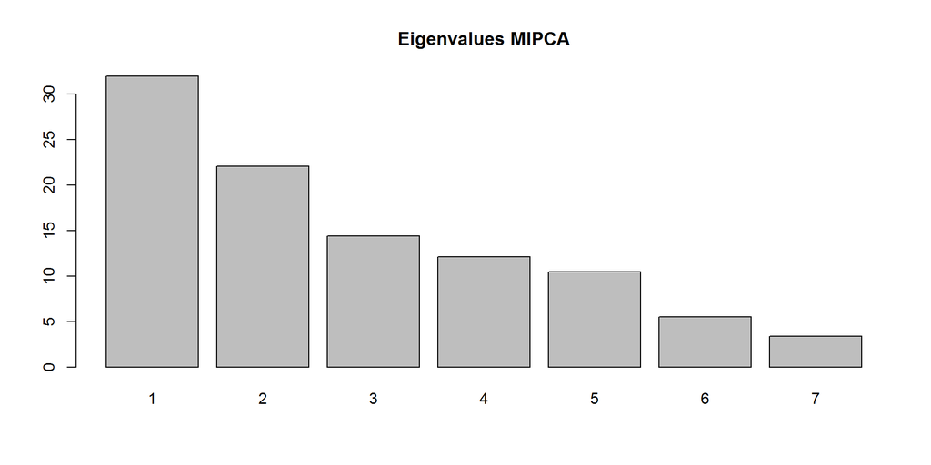

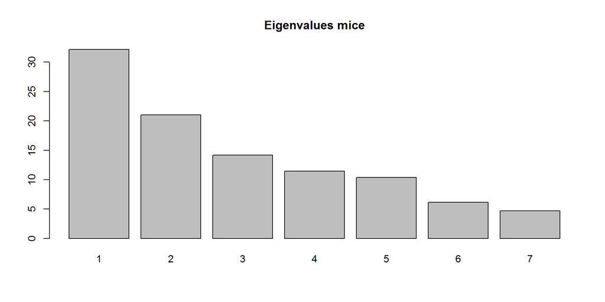

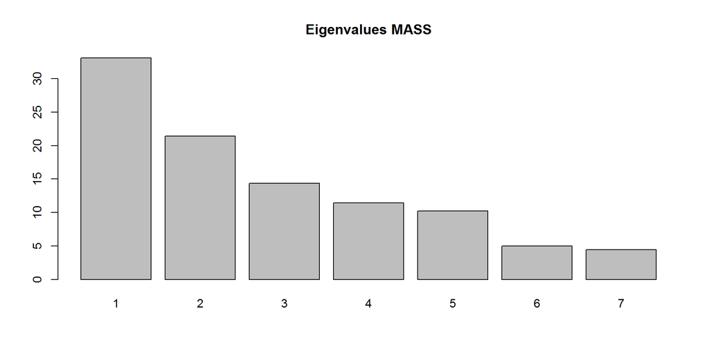

#### 2. Graphiques : nuage des individus et cercle de qualité des projections

- Données Pima complétées avec la méthode MIPCA du package MissMDA

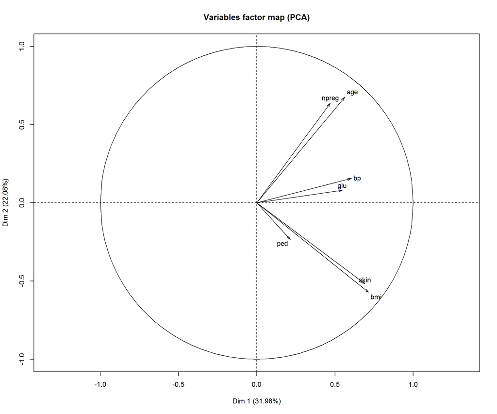

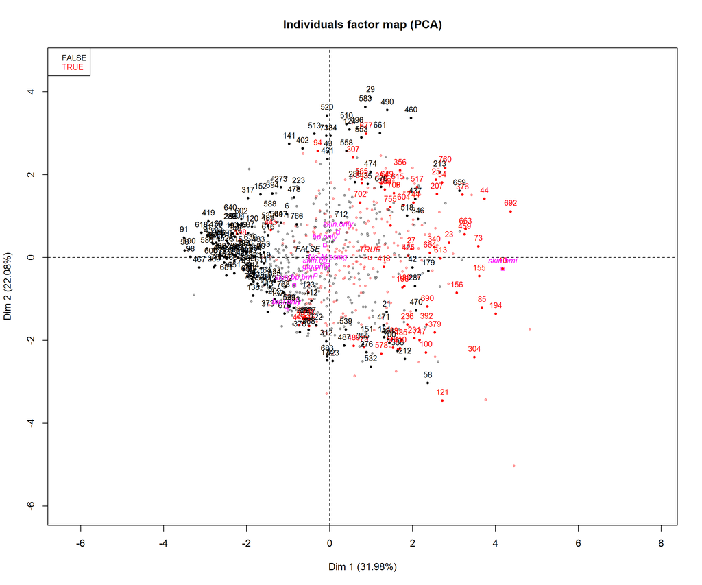

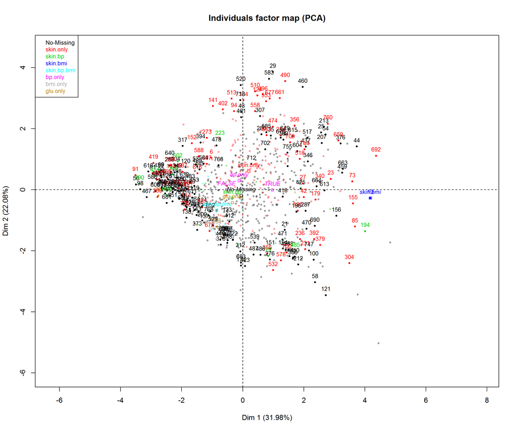

* Données Pima complétées avec la méthode mice du package mice

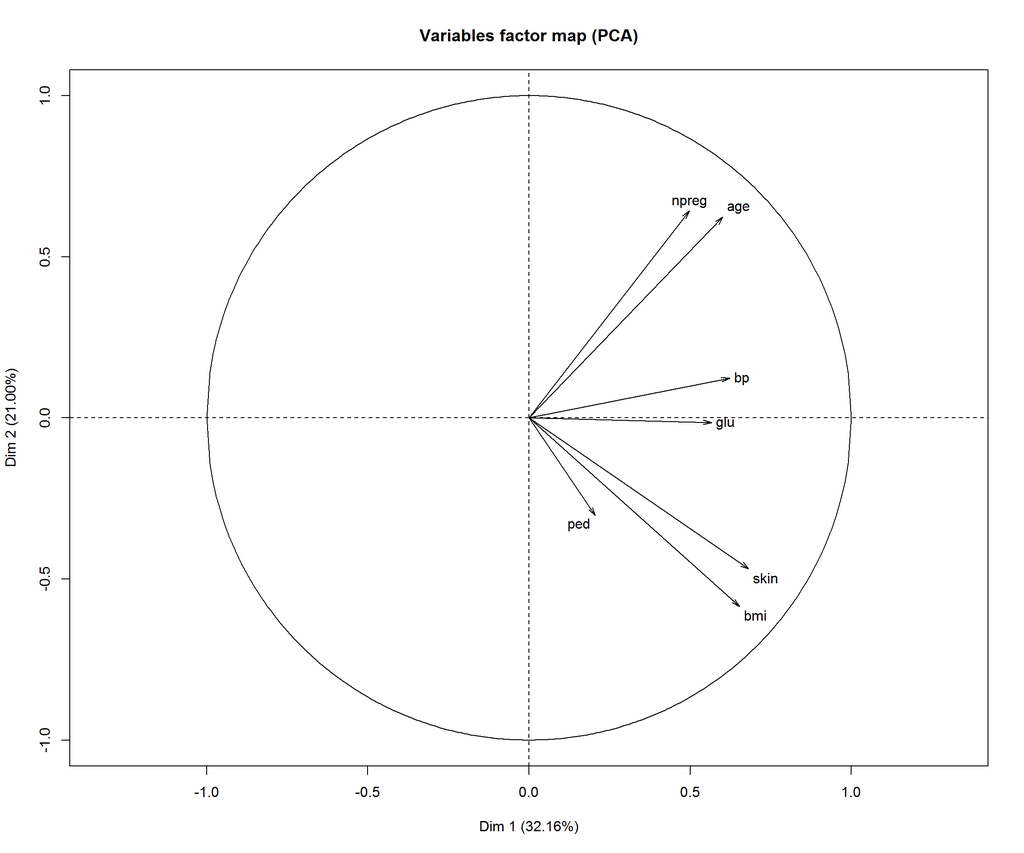

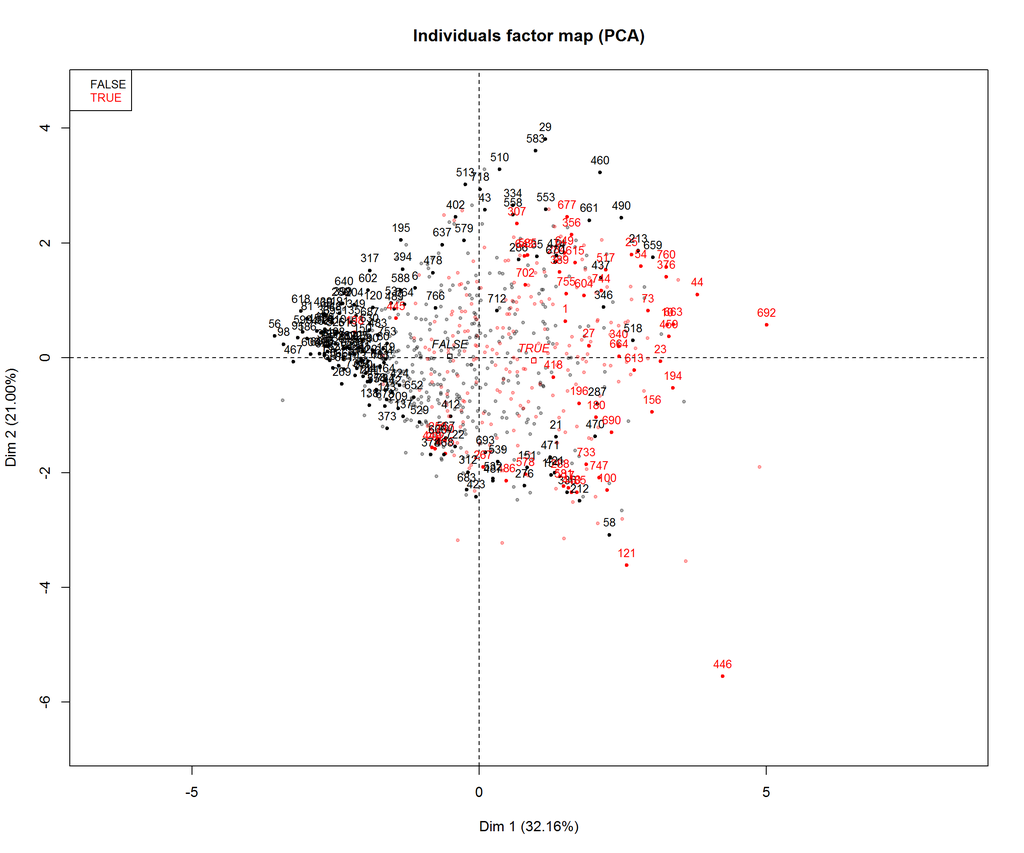

- Données Pima de la librairie MASS (données manquantes supprimées?)

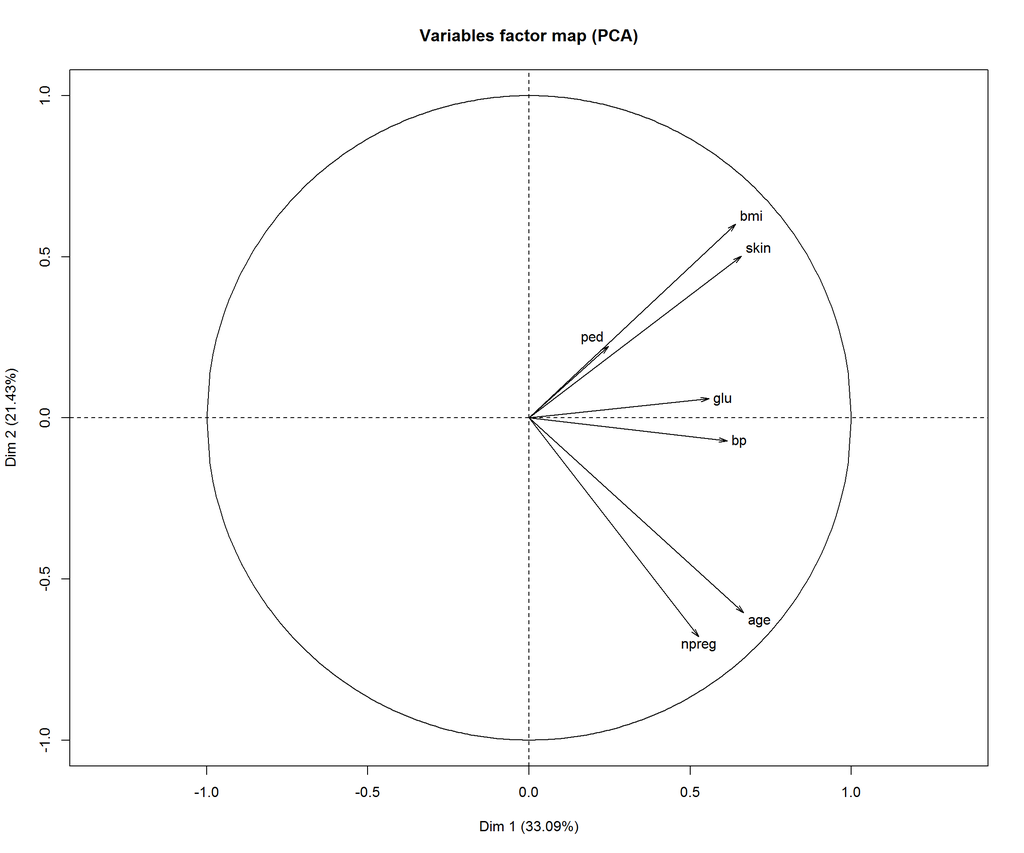

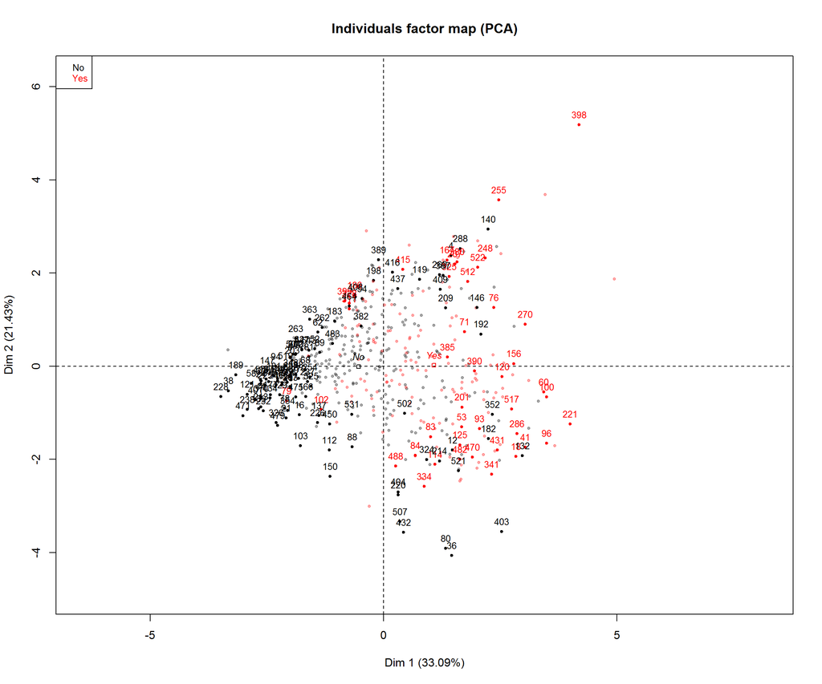

Remarque: Les données complétés par MICE et MIPCA ont une PCA similaire. Par contre pour les données de MASS on a une transformation par rapport aux axes. Même forme mais symétrique / à l’axe principal.

#### 3. coefficients de corrélation entre chacunes des variables et les 5 premières composantes principales

```r
dimdesc <- dimdesc(res.pca, proba=1e-5) #, nbelements = 16)
dimdesc
```

```
## $Dim.1
## $Dim.1$quanti
##       correlation       p.value
## bmi     0.7147642 1.865248e-120
## skin    0.6924074 3.972111e-110
## bp      0.6054492  1.334391e-77
## age     0.5628754  4.623614e-65
## glu     0.5456233  1.764392e-60
## npreg   0.4700395  2.991143e-43
## ped     0.2153314  1.823381e-09
##
## $Dim.1$quali
##             R2      p.value
## type 0.2299611 3.462915e-45
##
## $Dim.1$category
##              Estimate      p.value
## type=TRUE   0.7517656 3.462915e-45
## type=FALSE -0.7517656 3.462915e-45
##
##
## $Dim.2
## $Dim.2$quanti
##       correlation       p.value
## age     0.6762506 3.110317e-103
## npreg   0.6372813  2.708870e-88
## ped    -0.2347030  5.076862e-11
## skin   -0.5183952  9.066742e-54
## bmi    -0.5723898  1.048861e-67
##
## $Dim.2$quali
##                      R2     p.value
## missingCateg 0.08295135 1.09753e-11
##
## $Dim.2$category
##                           Estimate      p.value
## missingCateg=skin.only  0.87796836 2.495901e-15
## missingCateg=No-Missing 0.08341254 1.752248e-10
##
##
## $Dim.3
## $Dim.3$quanti
##      correlation       p.value
## ped    0.8476249 6.345822e-212
## glu    0.4014947  5.867957e-31
## bmi   -0.1730406  1.498407e-06
## skin  -0.2615065  2.064871e-13
##
## $Dim.3$quali
##              R2      p.value
## type 0.03351702 3.484204e-07
##
## $Dim.3$category
##              Estimate      p.value
## type=TRUE   0.1926297 3.484204e-07
## type=FALSE -0.1926297 3.484204e-07
```

##### Graphique de corrélation avec corrplot

```
##       Dim.1 Dim.2 Dim.3 Dim.4 Dim.5
## npreg  0.47  0.64 -0.13  0.46 -0.09
## glu    0.55  0.08  0.40 -0.44 -0.57
## bp     0.61  0.16 -0.10 -0.52  0.55
## skin   0.69 -0.52 -0.26  0.26 -0.09
## bmi    0.71 -0.57 -0.17  0.06  0.00
## ped    0.22 -0.23  0.85  0.31  0.29
## age    0.56  0.68  0.05  0.10  0.05
```

```
##       Dim.1 Dim.2 Dim.3 Dim.4 Dim.5
## npreg  0.50  0.64 -0.01  0.39 -0.15
## glu    0.57 -0.01  0.33 -0.62 -0.41
## bp     0.62  0.12 -0.22 -0.33  0.65
## skin   0.68 -0.47 -0.23  0.26 -0.20
## bmi    0.65 -0.58 -0.20  0.13 -0.01
## ped    0.21 -0.30  0.85  0.25  0.27
## age    0.60  0.62  0.12  0.09 -0.01
```

```
##       Dim.1 Dim.2 Dim.3 Dim.4 Dim.5
## npreg  0.53 -0.68 -0.01  0.32 -0.13
## glu    0.56  0.06  0.33 -0.64 -0.40
## bp     0.61 -0.07 -0.30 -0.34  0.63
## skin   0.66  0.50 -0.19  0.30 -0.21
## bmi    0.64  0.60 -0.18  0.14 -0.02
## ped    0.25  0.22  0.86  0.22  0.33
## age    0.67 -0.60  0.05  0.09 -0.04
```

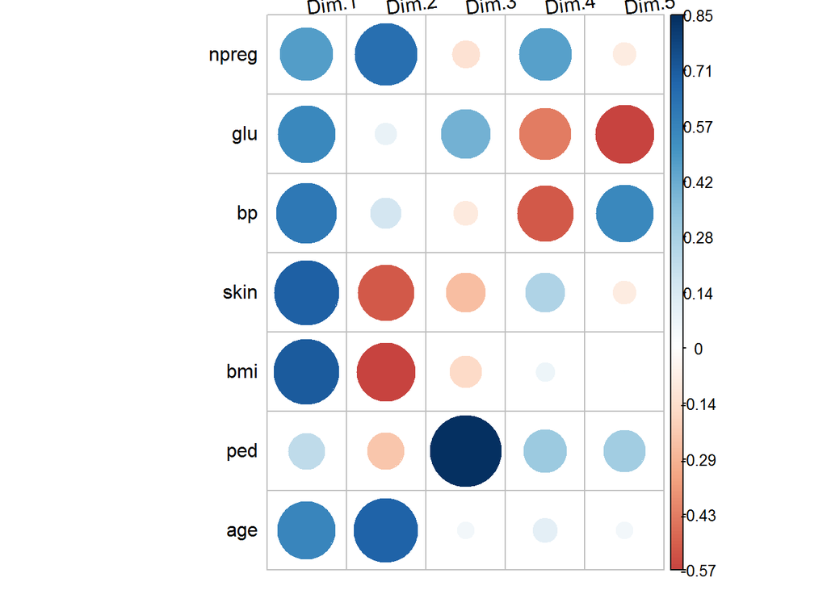

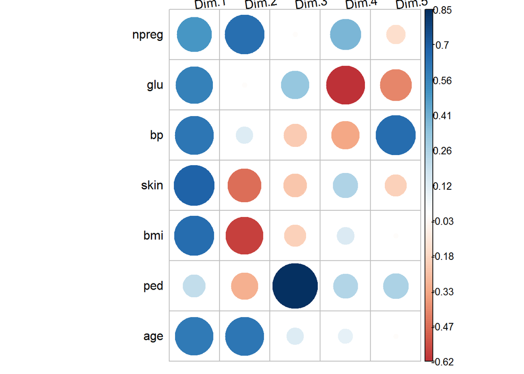

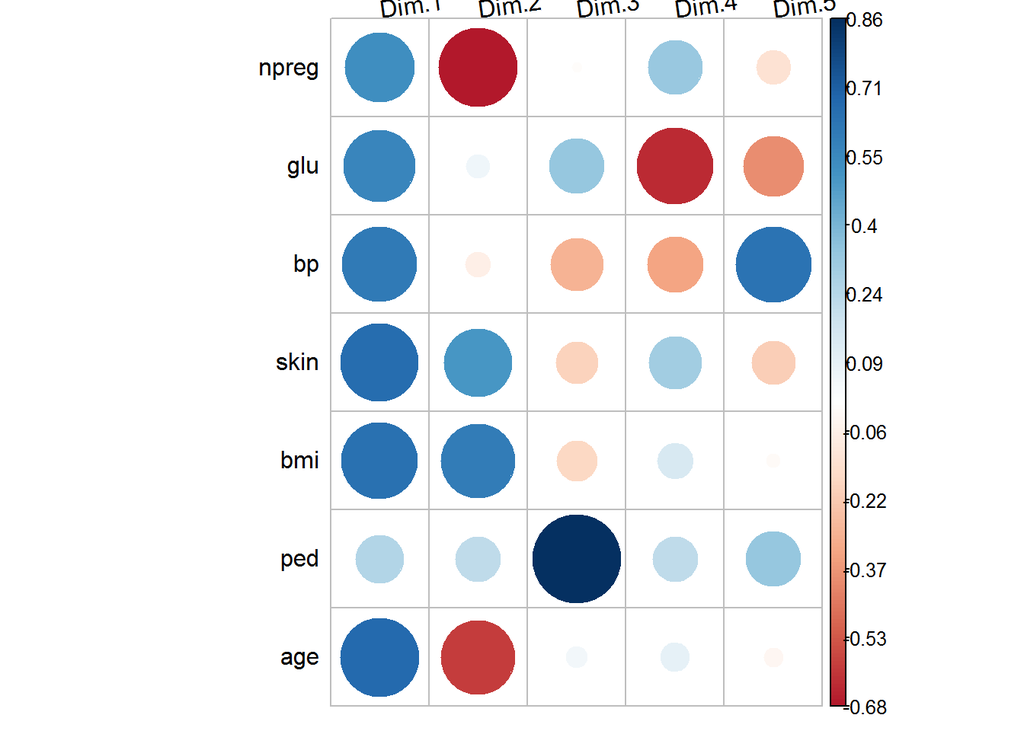

#### 4. Indice de qualité de la représentation cos2

```
##       Dim.1 Dim.2 Dim.3 Dim.4 Dim.5
## npreg  0.22  0.41  0.02  0.21  0.01
## glu    0.30  0.01  0.16  0.20  0.33
## bp     0.37  0.02  0.01  0.27  0.30
## skin   0.48  0.27  0.07  0.07  0.01
## bmi    0.51  0.33  0.03  0.00  0.00
## ped    0.05  0.06  0.72  0.09  0.08
## age    0.32  0.46  0.00  0.01  0.00
```

```
##       Dim.1 Dim.2 Dim.3 Dim.4 Dim.5
## npreg  0.25  0.41  0.00  0.15  0.02
## glu    0.32  0.00  0.11  0.39  0.17
## bp     0.39  0.02  0.05  0.11  0.42
## skin   0.46  0.22  0.05  0.07  0.04
## bmi    0.43  0.34  0.04  0.02  0.00
## ped    0.04  0.09  0.73  0.06  0.07
## age    0.36  0.39  0.01  0.01  0.00
```

```
##       Dim.1 Dim.2 Dim.3 Dim.4 Dim.5
## npreg  0.28  0.46  0.00  0.10  0.02
## glu    0.31  0.00  0.11  0.41  0.16
## bp     0.38  0.01  0.09  0.12  0.39
## skin   0.43  0.25  0.04  0.09  0.04
## bmi    0.41  0.36  0.03  0.02  0.00
## ped    0.06  0.05  0.74  0.05  0.11
## age    0.44  0.37  0.00  0.01  0.00
```

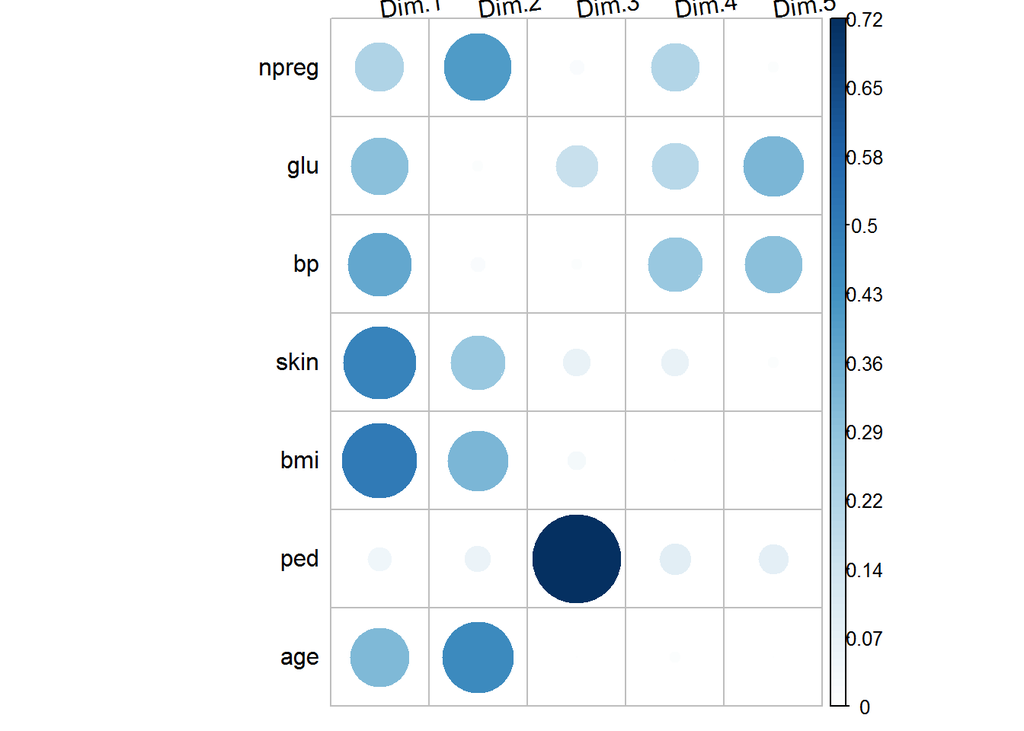

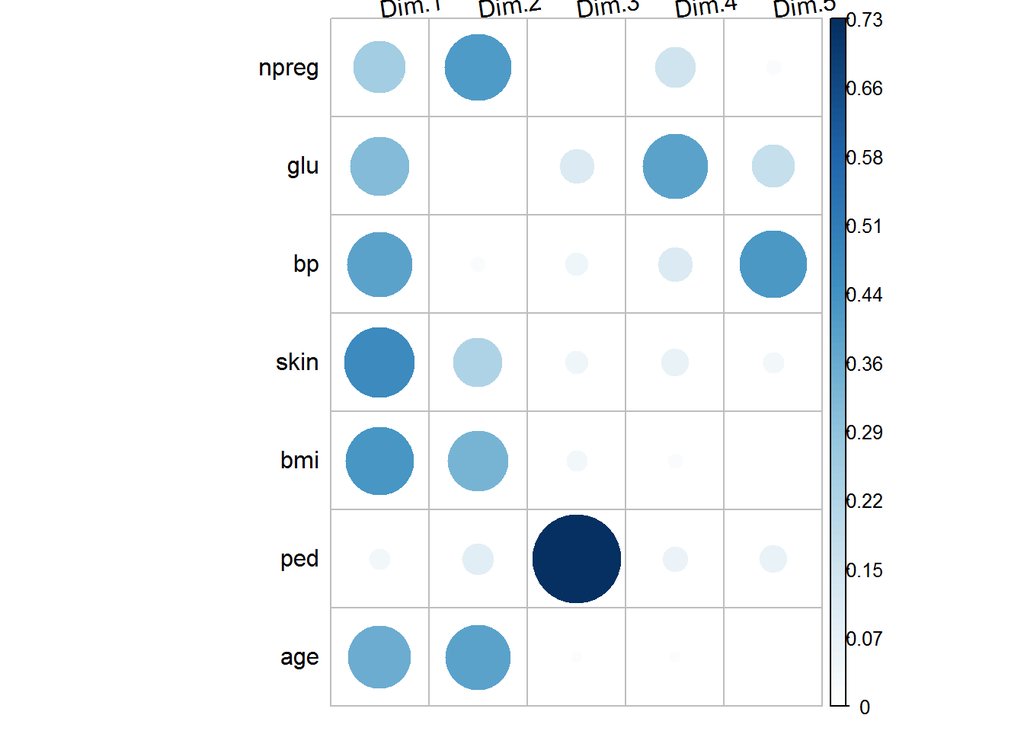

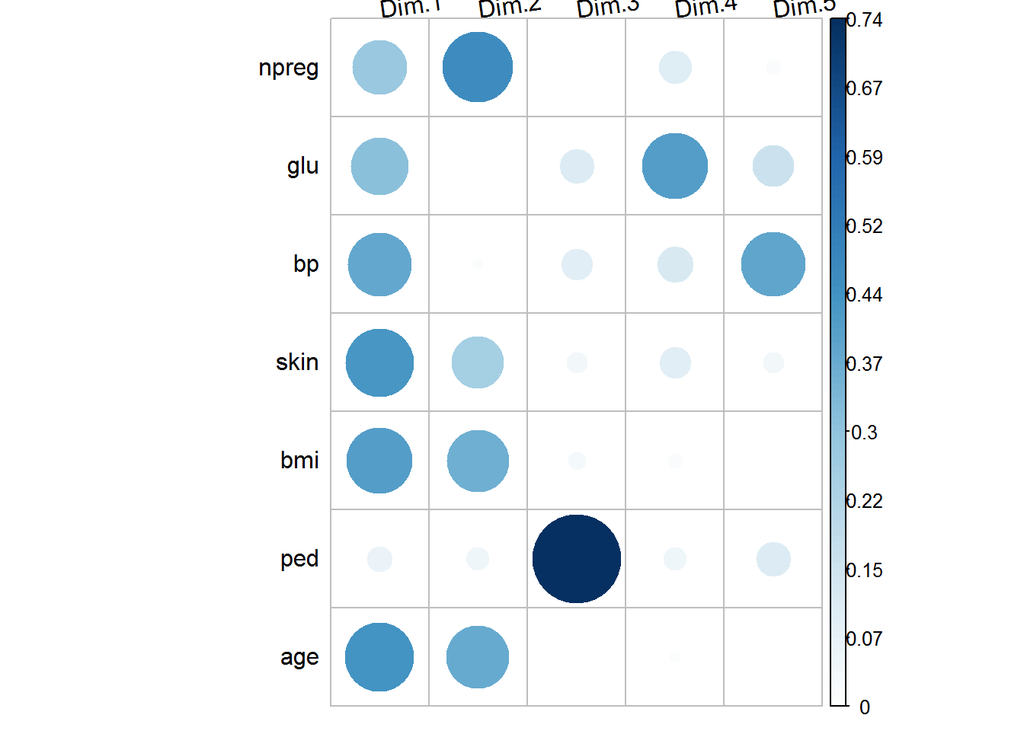

#### 5. Contribution des variables à la construction des axes

```
##       Dim.1 Dim.2 Dim.3 Dim.4 Dim.5
## npreg  9.87 26.27  1.76 24.67  1.12
## glu   13.30  0.42 15.98 23.18 45.13
## bp    16.37  1.58  1.03 31.82 40.57
## skin  21.42 17.39  6.78  7.77  1.23
## bmi   22.82 21.20  2.97  0.44  0.00
## ped    2.07  3.56 71.24 11.03 11.54
## age   14.15 29.59  0.24  1.09  0.40
```

```
##       Dim.1 Dim.2 Dim.3 Dim.4 Dim.5
## npreg 10.99 28.06  0.02 18.83  3.05
## glu   14.24  0.01 10.93 48.43 23.57
## bp    17.22  1.04  4.90 13.50 57.93
## skin  20.62 14.92  5.22  8.55  5.27
## bmi   18.97 23.27  4.20  1.98  0.03
## ped    1.88  6.24 73.36  7.78 10.12
## age   16.08 26.46  1.37  0.94  0.03
```

```
##       Dim.1 Dim.2 Dim.3 Dim.4 Dim.5
## npreg 11.95 30.81  0.00 13.04  2.41
## glu   13.46  0.24 10.71 51.52 22.05
## bp    16.31  0.34  9.15 14.83 54.60
## skin  18.74 16.79  3.56 11.20  5.95
## bmi   17.75 24.14  3.24  2.59  0.06
## ped    2.62  3.30 73.06  5.89 14.75
## age   19.17 24.39  0.28  0.92  0.19
```

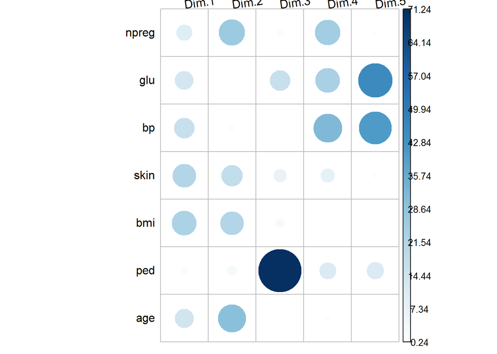

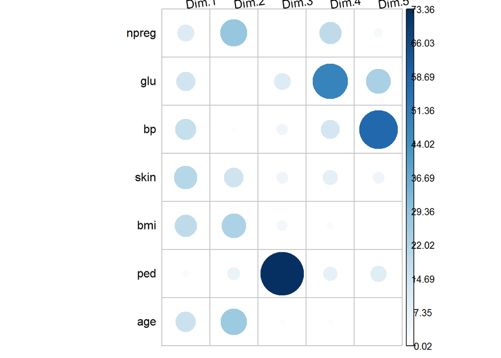

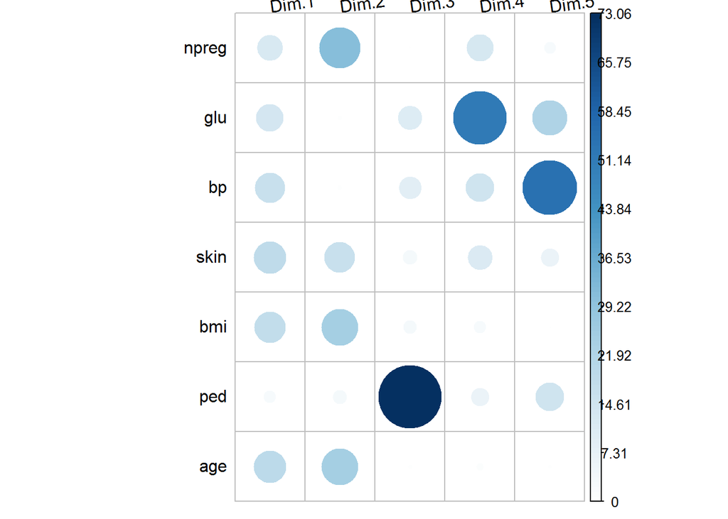

Intérêt : Les données Pima sont très utilsées (cf. Kaggle) pour autant il ne semble pas qu’un modèle d’inputation ait été utilisé. Bien souvent les données manquantes sont supprimés ou bien imputatikon simple par moyenne.

### Annexe 2 : Autres méthodes MIPCA